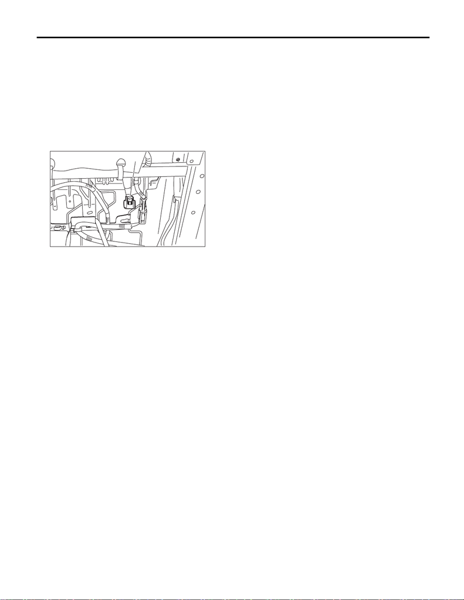

Airbag Connector

OCCUPANT DETECTION SYSTEM (DIAGNOSTICS)

5. Airbag Connector

A: PROCEDURE

NESS)

1) How to disconnect:

Press the lock arm (A) and disconnect the connector.

CAUTION:

ness.

2) How to connect:

Holding the connector, push it in securely until a clicking sound is heard.

CAUTION:

Be sure to insert the connector in until it is locked. Then pull it gently to make sure that it is locked.

2. AIRBAG CONTROL MODULE

Connector.>

3. BUCKLE SWITCH RH

tor.>